# Dokumentacja projektu PMLR

Paweł Piorun, Ewa Rycaj

Warszawa 2020

# Badanie czynników wpływających na rozwody małżeństw

## 1. Cel projektu

- Analiza bazy danych dotyczącej rozwodów wśród osób ankietowanych,
- Utworzenie modelu opisującego prawdopodobieństwo rozwodu poprzez klasyfikację danych na dwie klasy wyjściowe (Divorced / Not divorced),
- Podział zbioru na podzbiór trenujący i testowy,
- Uwzględnienie metod zmniejszenia wymiarowości problemu - określenie niepotrzebnych parametrów i usunięcie ich z analizy,
- Sprwadzenie modelu oraz jego poprawki w celu ewentualnego zwiększenia dokładności.

## 2. Opis danych

Dane wejściowe to baza danych z wynikami ankiet dotyczących relacji osób w związkach. Każda ankieta zawiera 54 pytań, z odpowiedziami w formie liczby całkowitej od 0 do 4 (5 wartości). Skala ta jest w przybliżeniu skalą Likerta i przekłada się na odpowiedź w następujący sposób:

- 0: Tak
- 1: Raczej tak
- 2: Trudno powiedzieć
- 3: Raczej nie
- 4: Nie

Spośród wszystkich ankietowanych **84** osoby były rozwiedzione (49%) oraz **86** osób w małżeństwie (51%). Suma obserwacji wynosi **170**. Niezrównoważenie danych jest więc niewielkie.

Klasyfikację ankietowanych na rozwiedzionych i nierozwiedzionych przedstawia ostatnia kolumna danych zawierająca wartości:

- 1 - Divorced
- 0 - Married / Not divorced

Bazę danych wraz z opisem zaczerpnięto z portalu UCI Machine Learning Repository:  
https://archive.ics.uci.edu/ml/datasets/Divorce+Predictors+data+set

Bardziej szczegółowy opis danych można znaleźć w streszczeniu artykułu, który był rezultatem przeprowadzanych ankiet i badań:

Yöntem, M , Adem, K , İlhan, T , Kılıçarslan, S. (2019). DIVORCE PREDICTION USING CORRELATION BASED FEATURE SELECTION AND ARTIFICIAL NEURAL NETWORKS. Nevşehir Hacı Bektaş Veli University SBE Dergisi, 9 (1), 259-273.  
https://dergipark.org.tr/tr/pub/nevsosbilen/issue/46568/549416  
https://dergipark.org.tr/tr/download/article-file/748448

Poniżej przedstawiono listę pytań w ankiecie:

1. If one of us apologizes when our discussion deteriorates, the discussion ends.
2. I know we can ignore our differences, even if things get hard sometimes.
3. When we need it, we can take our discussions with my spouse from the beginning and correct it.
4. When I discuss with my spouse, to contact him will eventually work.
5. The time I spent with my wife is special for us.
6. We don’t have time at home as partners.
7. We are like two strangers who share the same environment at home rather than family.
8. I enjoy our holidays with my wife.
9. I enjoy traveling with my wife.
10. Most of our goals are common to my spouse.
11. I think that one day in the future, when I look back, I see that my spouse and I have been in harmony with each other.
12. My spouse and I have similar values in terms of personal freedom.
13. My spouse and I have similar sense of entertainment.
14. Most of our goals for people (children, friends, etc.) are the same.
15. Our dreams with my spouse are similar and harmonious.
16. We’re compatible with my spouse about what love should be.
17. We share the same views about being happy in our life with my spouse
18. My spouse and I have similar ideas about how marriage should be
19. My spouse and I have similar ideas about how roles should be in marriage
20. My spouse and I have similar values in trust.
21. I know exactly what my wife likes.
22. I know how my spouse wants to be taken care of when she/he sick.
23. I know my spouse’s favorite food.
24. I can tell you what kind of stress my spouse is facing in her/his life.
25. I have knowledge of my spouse’s inner world.
26. I know my spouse’s basic anxieties.
27. I know what my spouse’s current sources of stress are.
28. I know my spouse’s hopes and wishes.
29. I know my spouse very well.
30. I know my spouse’s friends and their social relationships.
31. I feel aggressive when I argue with my spouse.
32. When discussing with my spouse, I usually use expressions such as ‘you always’ or ‘you never’ .
33. I can use negative statements about my spouse’s personality during our discussions.
34. I can use offensive expressions during our discussions.
35. I can insult my spouse during our discussions.
36. I can be humiliating when we discussions.
37. My discussion with my spouse is not calm.
38. I hate my spouse’s way of open a subject.
39. Our discussions often occur suddenly.
40. We’re just starting a discussion before I know what’s going on.
41. When I talk to my spouse about something, my calm suddenly breaks.
42. When I argue with my spouse, ı only go out and I don’t say a word.
43. I mostly stay silent to calm the environment a little bit.
44. Sometimes I think it’s good for me to leave home for a while.
45. I’d rather stay silent than discuss with my spouse.
46. Even if I’m right in the discussion, I stay silent to hurt my spouse.
47. When I discuss with my spouse, I stay silent because I am afraid of not being able to control my anger.
48. I feel right in our discussions.
49. I have nothing to do with what I’ve been accused of.
50. I’m not actually the one who’s guilty about what I’m accused of.
51. I’m not the one who’s wrong about problems at home.
52. I wouldn’t hesitate to tell my spouse about her/his inadequacy.
53. When I discuss, I remind my spouse of her/his inadequacy.
54. I’m not afraid to tell my spouse about her/his incompetence.

## 3. Przygotowanie danych do analizy

Wczytywanie oraz przygotowanie danych zostało zawarte w skrypcie **loadingData.R**:

```r
# Read data with first row as headers row
data <- read.table("divorce.csv", sep = ';', header = T)

# Show column names
colnames(data)
```

```
##  [1] "Atr1"  "Atr2"  "Atr3"  "Atr4"  "Atr5"  "Atr6"  "Atr7"  "Atr8"  "Atr9"
## [10] "Atr10" "Atr11" "Atr12" "Atr13" "Atr14" "Atr15" "Atr16" "Atr17" "Atr18"
## [19] "Atr19" "Atr20" "Atr21" "Atr22" "Atr23" "Atr24" "Atr25" "Atr26" "Atr27"
## [28] "Atr28" "Atr29" "Atr30" "Atr31" "Atr32" "Atr33" "Atr34" "Atr35" "Atr36"
## [37] "Atr37" "Atr38" "Atr39" "Atr40" "Atr41" "Atr42" "Atr43" "Atr44" "Atr45"
## [46] "Atr46" "Atr47" "Atr48" "Atr49" "Atr50" "Atr51" "Atr52" "Atr53" "Atr54"
## [55] "Class"
```

```r
#Show data
head(data)
```

```
##   Atr1 Atr2 Atr3 Atr4 Atr5 Atr6 Atr7 Atr8 Atr9 Atr10 Atr11 Atr12 Atr13 Atr14
## 1    2    2    4    1    0    0    0    0    0     0     1     0     1     1
## 2    4    4    4    4    4    0    0    4    4     4     4     3     4     0
## 3    2    2    2    2    1    3    2    1    1     2     3     4     2     3
## 4    3    2    3    2    3    3    3    3    3     3     4     3     3     4
## 5    2    2    1    1    1    1    0    0    0     0     0     1     0     1
## 6    0    0    1    0    0    2    0    0    0     1     0     2     1     0
##   Atr15 Atr16 Atr17 Atr18 Atr19 Atr20 Atr21 Atr22 Atr23 Atr24 Atr25 Atr26 Atr27
## 1     0     1     0     0     0     1     0     0     0     0     0     0     0
## 2     4     4     4     4     3     2     1     1     0     2     2     1     2
## 3     3     3     3     3     3     2     1     0     1     2     2     2     2
## 4     3     3     3     3     3     4     1     1     1     1     2     1     1
## 5     1     1     1     1     2     1     1     0     0     0     0     2     1
## 6     2     0     2     1     0     1     0     0     0     0     2     2     0
##   Atr28 Atr29 Atr30 Atr31 Atr32 Atr33 Atr34 Atr35 Atr36 Atr37 Atr38 Atr39 Atr40
```

[output cut: 20 more lines]

```r
# Prepare output
data$Class <- as.factor(data$Class)
levels(data$Class) <- c("Not divorced", "Divorced")

# Show data
head(data)
```

```
##   Atr1 Atr2 Atr3 Atr4 Atr5 Atr6 Atr7 Atr8 Atr9 Atr10 Atr11 Atr12 Atr13 Atr14
## 1    2    2    4    1    0    0    0    0    0     0     1     0     1     1
## 2    4    4    4    4    4    0    0    4    4     4     4     3     4     0
## 3    2    2    2    2    1    3    2    1    1     2     3     4     2     3
## 4    3    2    3    2    3    3    3    3    3     3     4     3     3     4
## 5    2    2    1    1    1    1    0    0    0     0     0     1     0     1
## 6    0    0    1    0    0    2    0    0    0     1     0     2     1     0
##   Atr15 Atr16 Atr17 Atr18 Atr19 Atr20 Atr21 Atr22 Atr23 Atr24 Atr25 Atr26 Atr27
## 1     0     1     0     0     0     1     0     0     0     0     0     0     0
## 2     4     4     4     4     3     2     1     1     0     2     2     1     2
## 3     3     3     3     3     3     2     1     0     1     2     2     2     2
## 4     3     3     3     3     3     4     1     1     1     1     2     1     1
## 5     1     1     1     1     2     1     1     0     0     0     0     2     1
## 6     2     0     2     1     0     1     0     0     0     0     2     2     0
##   Atr28 Atr29 Atr30 Atr31 Atr32 Atr33 Atr34 Atr35 Atr36 Atr37 Atr38 Atr39 Atr40
```

[output cut: 20 more lines]

```r
summary(data$Class)
```

```
## Not divorced     Divorced
##           86           84
```

## 4. Niezbalansowanie danych

Ze względu na bardzo małe niezbalansowanie danych, postanowiono użyć *upsampling’u* danych, który w tym wypadku doda 2 obserwacje o klasie Divorced.

```r
#Up sample the data (this will add two more Divorced observations)
data <- caret::upSample(x = data[,-55], y = data$Class)
summary(data$Class)
```

```
## Not divorced     Divorced
##           86           86
```

## 5. Wizualna analiza eksploracyjna

Przy analizie eksploracyjnej posłużono się:

- box-plotami pokazującymi wartości parametrów przyjmowane dla obu klas
- mapą ciepła pokazującą korelację między parametrami

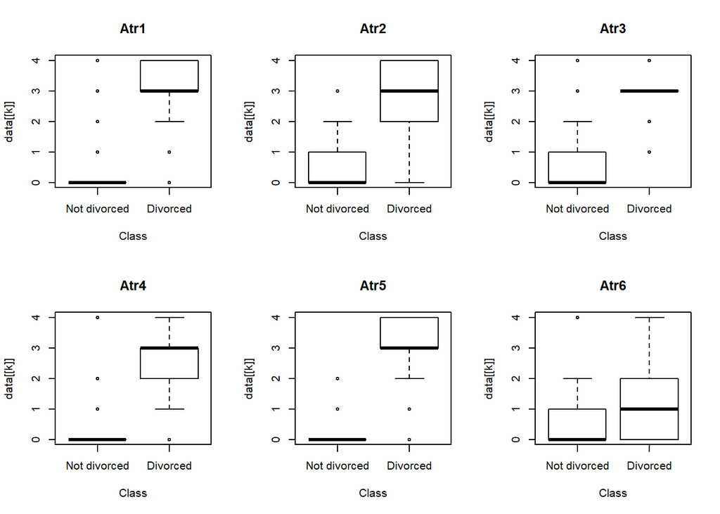

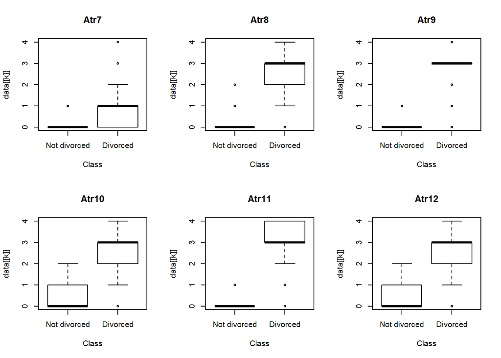

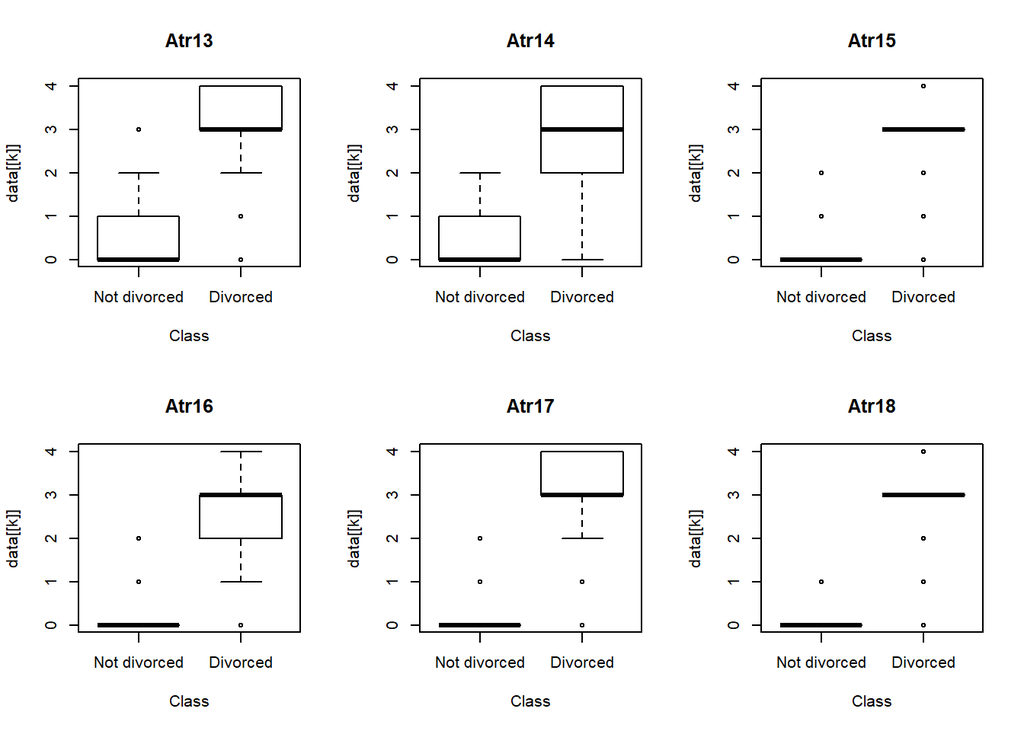

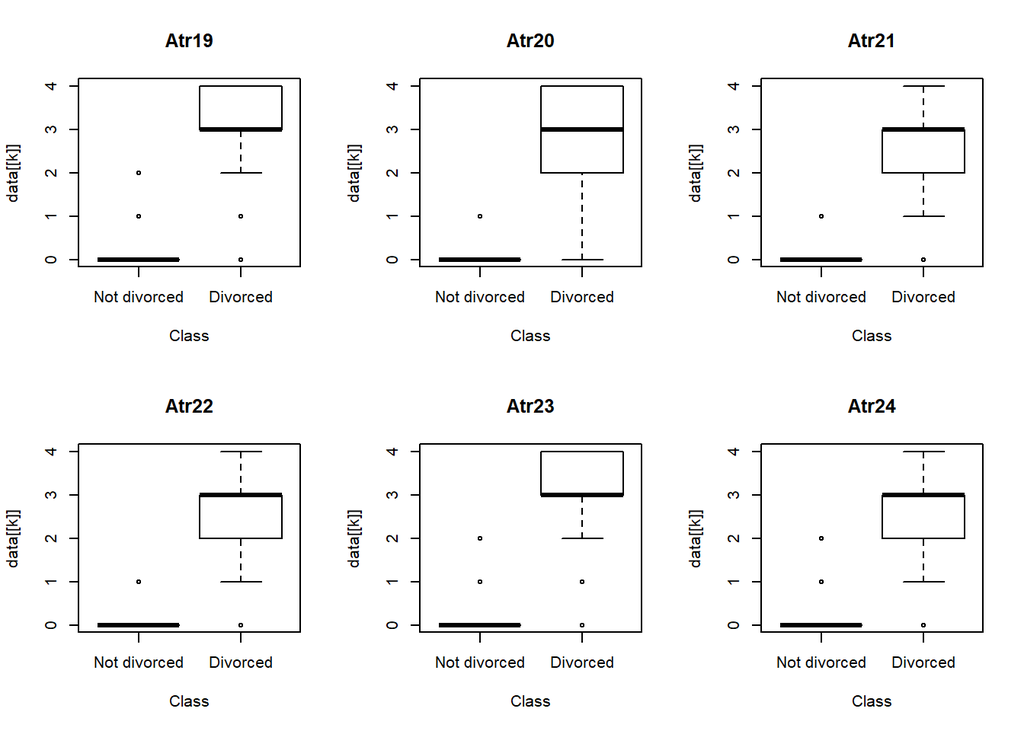

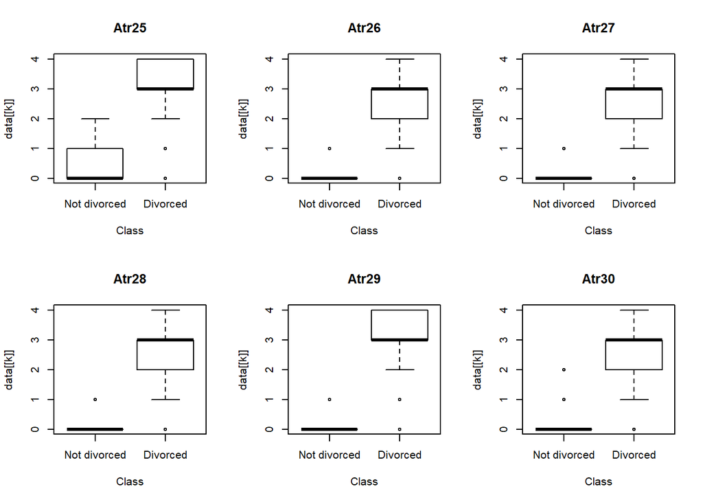

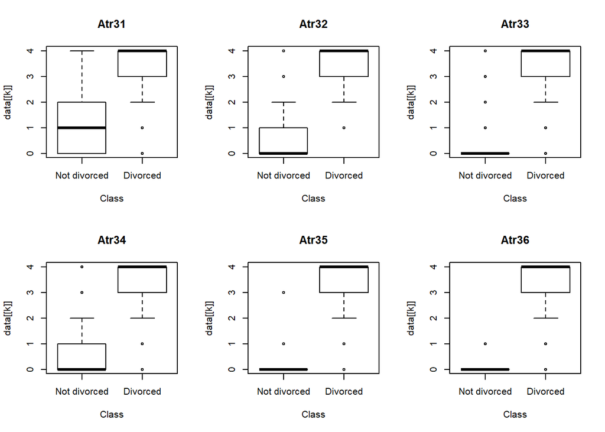

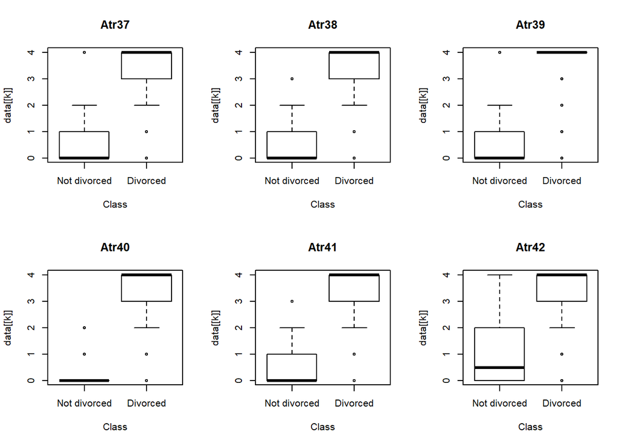

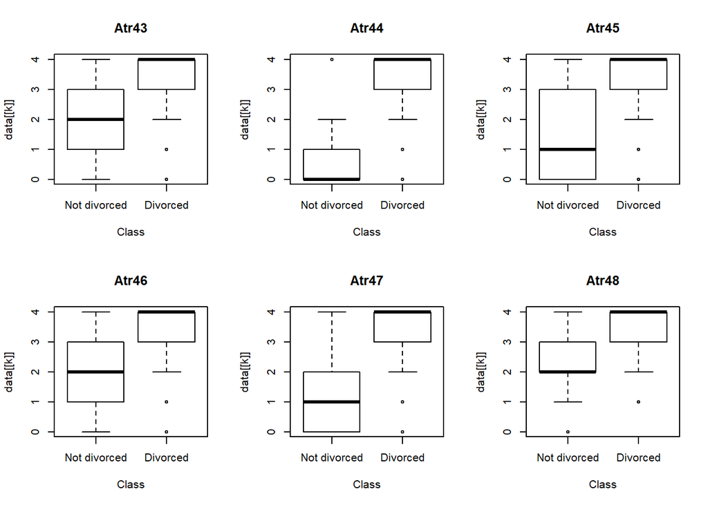

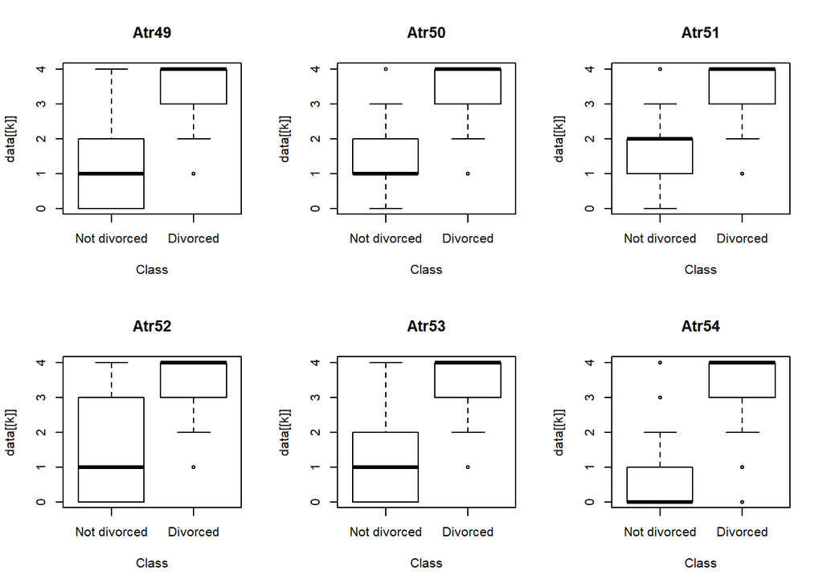

```r
#Add box plots in packages of 2x3, so 9 times 6 = 54 attributes
for (i in 1:9)
{
  # Prepare plot space
  par(mfrow=c(2,3))
  for (j in 1:6)
  {
    # Show plot
    k = (i-1)*6+j
    boxplot(data[[k]] ~ Class, data = data, main=names(data)[k])
  }
}; rm(i); rm(j); rm(k)
```

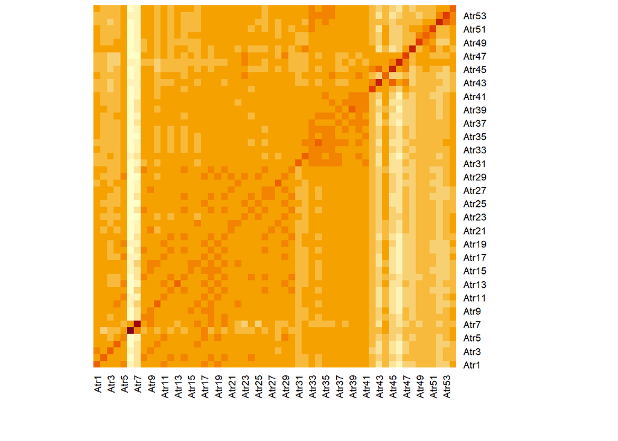

```r
# Show heatmap of correlations
# The darker the square, the more correlated it is.
heatmap(cor(data[,-55]), Rowv=NA, Colv=NA)
```

## 6. Wnioski z analizy grupowań

Największe wymieszanie wykazują atrybuty nr 6 i 7, co mogło być spowodowane niejasnym sformułowaniem pytania, lub przyjętą konwencją prawdy przez osobę ankietowaną (czy odpowiedź “Tak” znaczy że nie mamy czasu, czy odpowiedź “Nie, nie mamy czasu”):

6. We don’t have time at home as partners.
7. We are like two strangers who share the same environment at home rather than family.

Co więcej, pytania 43, 45, 46 oraz 52 wykazują szeroki zakres odpowiedzi dla klasy Not Divorced:

43. I mostly stay silent to calm the environment a little bit.
44. I’d rather stay silent than discuss with my spouse.
45. Even if I’m right in the discussion, I stay silent to hurt my spouse.
46. I wouldn’t hesitate to tell my spouse about her/his inadequacy.

Wszystkie parametry skorelowane są dodatnio.

## 7. Analiza możliwości redukcji wymiarowości

W celu redukcji wymiarowości przeprowadzono analizę PCA:

```r
# Check PCA with normalized data
pca1 <- prcomp(data[,-55], center = TRUE, scale. = TRUE)
summary(pca1)
```

```
## Importance of components:
##                           PC1     PC2     PC3     PC4     PC5     PC6     PC7
## Standard deviation     6.3401 1.47823 1.19348 1.08905 0.94470 0.89042 0.83393
## Proportion of Variance 0.7444 0.04047 0.02638 0.02196 0.01653 0.01468 0.01288
## Cumulative Proportion  0.7444 0.78484 0.81122 0.83318 0.84971 0.86439 0.87727
##                            PC8     PC9    PC10   PC11    PC12    PC13    PC14
## Standard deviation     0.77250 0.75129 0.73140 0.6533 0.62152 0.60006 0.56222
## Proportion of Variance 0.01105 0.01045 0.00991 0.0079 0.00715 0.00667 0.00585
## Cumulative Proportion  0.88832 0.89877 0.90868 0.9166 0.92374 0.93041 0.93626
##                          PC15    PC16    PC17    PC18    PC19    PC20    PC21
## Standard deviation     0.5299 0.52256 0.50013 0.46746 0.44794 0.43590 0.41705
## Proportion of Variance 0.0052 0.00506 0.00463 0.00405 0.00372 0.00352 0.00322
## Cumulative Proportion  0.9415 0.94652 0.95115 0.95520 0.95891 0.96243 0.96565
##                           PC22    PC23    PC24    PC25    PC26   PC27    PC28
## Standard deviation     0.40446 0.37064 0.36151 0.34369 0.32654 0.3200 0.31532
## Proportion of Variance 0.00303 0.00254 0.00242 0.00219 0.00197 0.0019 0.00184
## Cumulative Proportion  0.96868 0.97123 0.97365 0.97583 0.97781 0.9797 0.98155
##                           PC29    PC30    PC31   PC32    PC33    PC34    PC35
## Standard deviation     0.30640 0.29551 0.27797 0.2651 0.25544 0.24786 0.23156
## Proportion of Variance 0.00174 0.00162 0.00143 0.0013 0.00121 0.00114 0.00099
## Cumulative Proportion  0.98328 0.98490 0.98633 0.9876 0.98884 0.98998 0.99097
##                           PC36    PC37    PC38    PC39   PC40    PC41    PC42
## Standard deviation     0.23073 0.22240 0.21425 0.19863 0.1949 0.18685 0.17273
## Proportion of Variance 0.00099 0.00092 0.00085 0.00073 0.0007 0.00065 0.00055
## Cumulative Proportion  0.99196 0.99287 0.99372 0.99445 0.9952 0.99580 0.99636
##                           PC43    PC44   PC45    PC46    PC47    PC48    PC49
## Standard deviation     0.16644 0.15675 0.1465 0.14583 0.13392 0.12617 0.12199
## Proportion of Variance 0.00051 0.00046 0.0004 0.00039 0.00033 0.00029 0.00028
## Cumulative Proportion  0.99687 0.99732 0.9977 0.99812 0.99845 0.99874 0.99902
##                           PC50    PC51   PC52    PC53    PC54
## Standard deviation     0.11381 0.10837 0.1048 0.09792 0.08789
## Proportion of Variance 0.00024 0.00022 0.0002 0.00018 0.00014
## Cumulative Proportion  0.99926 0.99948 0.9997 0.99986 1.00000
```

```r
# Check PCA without normalizing
pca2 <- prcomp(data[,-55], center = FALSE, scale. = FALSE)
summary(pca2)
```

```
## Importance of components:
##                            PC1     PC2    PC3     PC4     PC5     PC6     PC7
## Standard deviation     16.6993 3.13519 1.8268 1.65635 1.37698 1.25601 1.21888
## Proportion of Variance  0.8857 0.03122 0.0106 0.00871 0.00602 0.00501 0.00472
## Cumulative Proportion   0.8857 0.91695 0.9275 0.93627 0.94229 0.94730 0.95202
##                            PC8     PC9    PC10    PC11    PC12    PC13    PC14
## Standard deviation     1.10888 1.08232 1.04764 0.97650 0.96922 0.90079 0.84547
## Proportion of Variance 0.00391 0.00372 0.00349 0.00303 0.00298 0.00258 0.00227
## Cumulative Proportion  0.95592 0.95964 0.96313 0.96616 0.96914 0.97172 0.97399
##                           PC15    PC16    PC17    PC18    PC19    PC20   PC21
## Standard deviation     0.82783 0.77636 0.76420 0.72346 0.70321 0.68036 0.6140
## Proportion of Variance 0.00218 0.00191 0.00185 0.00166 0.00157 0.00147 0.0012
## Cumulative Proportion  0.97617 0.97808 0.97994 0.98160 0.98317 0.98464 0.9858
##                           PC22    PC23   PC24    PC25    PC26   PC27    PC28
## Standard deviation     0.60052 0.56983 0.5613 0.53047 0.51687 0.5018 0.49977
## Proportion of Variance 0.00115 0.00103 0.0010 0.00089 0.00085 0.0008 0.00079
## Cumulative Proportion  0.98698 0.98801 0.9890 0.98991 0.99076 0.9916 0.99235
##                          PC29    PC30    PC31    PC32    PC33    PC34    PC35
## Standard deviation     0.4702 0.45406 0.41682 0.40396 0.38645 0.38037 0.36789
## Proportion of Variance 0.0007 0.00065 0.00055 0.00052 0.00047 0.00046 0.00043
## Cumulative Proportion  0.9930 0.99371 0.99426 0.99478 0.99525 0.99571 0.99614
##                          PC36    PC37    PC38    PC39   PC40    PC41    PC42
## Standard deviation     0.3559 0.34340 0.33061 0.32181 0.3059 0.29712 0.27300
## Proportion of Variance 0.0004 0.00037 0.00035 0.00033 0.0003 0.00028 0.00024
## Cumulative Proportion  0.9965 0.99692 0.99726 0.99759 0.9979 0.99817 0.99841
##                           PC43   PC44    PC45    PC46    PC47    PC48    PC49
## Standard deviation     0.25514 0.2522 0.24579 0.22806 0.21724 0.19947 0.19213
## Proportion of Variance 0.00021 0.0002 0.00019 0.00017 0.00015 0.00013 0.00012
## Cumulative Proportion  0.99861 0.9988 0.99901 0.99917 0.99932 0.99945 0.99957
##                           PC50   PC51    PC52    PC53    PC54
## Standard deviation     0.18815 0.1755 0.16312 0.15423 0.14105
## Proportion of Variance 0.00011 0.0001 0.00008 0.00008 0.00006
## Cumulative Proportion  0.99968 0.9998 0.99986 0.99994 1.00000
```

Powyższa analiza pokazuje, że 99% zmienności parametrów wyjaśnia:

- pierwszych 35 komponentów w przypadku danych znormalizowanych
- pierwszych 26 komponentów w przypadku danych “surowych”

Analiza PCA pokazuje więc, że możemy znacznie zredukować wymiarowość problemu. W przypadku używania części komponentów PC wymagałoby to jednak pracowania na “nowych” przekształconych danych.

W celu wyznaczenia najważniejszych parametrów zastosowano metodę Recursive Feature Elimination (RFE):

```r
# Use RFE method to check how can we reduce parameters number
set.seed(1)
results <- caret::rfe(data$Class ~ ., data, sizes=c(3,5,7,9,13,20,30,40,50),
                      rfeControl=caret::rfeControl(functions=caret::rfFuncs,
                                                   method="cv", number=10, verbose=FALSE));
print(results)
```

```
##
## Recursive feature selection
##
## Outer resampling method: Cross-Validated (10 fold)
##
## Resampling performance over subset size:
##
##  Variables Accuracy  Kappa AccuracySD KappaSD Selected
##          3   0.9757 0.9517    0.05118  0.1019        *
##          5   0.9757 0.9517    0.05118  0.1019
##          7   0.9757 0.9517    0.05118  0.1019
##          9   0.9757 0.9517    0.05118  0.1019
##         13   0.9757 0.9517    0.05118  0.1019
##         20   0.9757 0.9517    0.05118  0.1019
##         30   0.9757 0.9517    0.05118  0.1019
##         40   0.9757 0.9517    0.05118  0.1019
##         50   0.9757 0.9517    0.05118  0.1019
##         54   0.9757 0.9517    0.05118  0.1019
##
## The top 3 variables (out of 3):
##    Atr18, Atr40, Atr11
```

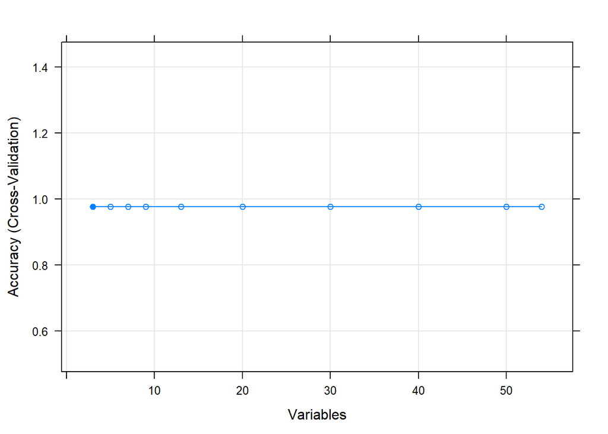

```r
plot(results, type=c("g", "o"))
```

```r
# Use RFE with different function
results2 <- caret::rfe(data$Class ~ ., data, sizes=c(1,2,3,5,7,9,13,20,30,40,50),
                      rfeControl=caret::rfeControl(functions=caret::nbFuncs,
                                                   method="cv", number=10, verbose=FALSE));
print(results2)
```

```
##
## Recursive feature selection
##
## Outer resampling method: Cross-Validated (10 fold)
##
## Resampling performance over subset size:
##
##  Variables Accuracy  Kappa AccuracySD KappaSD Selected
##          1   0.9650 0.9303    0.04099 0.08142
##          2   0.9653 0.9309    0.04848 0.09650
##          3   0.9771 0.9545    0.04053 0.08042        *
##          5   0.9771 0.9545    0.04053 0.08042
##          7   0.9771 0.9545    0.04053 0.08042
##          9   0.9771 0.9545    0.04053 0.08042
##         13   0.9771 0.9545    0.04053 0.08042
##         20   0.9771 0.9545    0.04053 0.08042
##         30   0.9771 0.9545    0.04053 0.08042
##         40   0.9771 0.9545    0.04053 0.08042
##         50   0.9771 0.9545    0.04053 0.08042
##         54   0.9771 0.9545    0.04053 0.08042
##
## The top 3 variables (out of 3):
##    Atr18, Atr20, Atr40
```

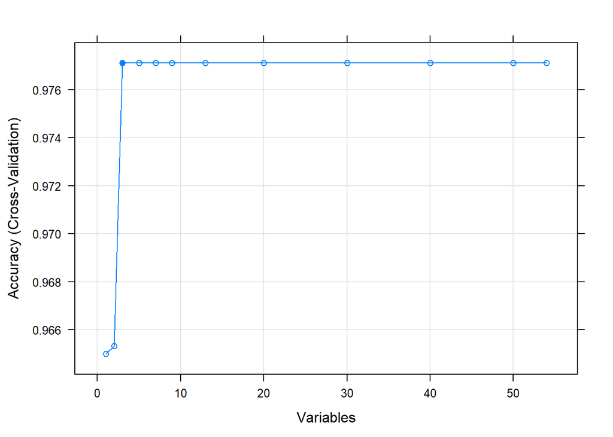

```r
plot(results2, type=c("g", "o"))
```

## 8. Podział danych i modelowanie

W projekcie zostały przeprowadzone dwa różne sposoby podziału danych. Podział losowy na dane treningowe i testowe oraz walidacja krzyżowa metodą Leave One Out. Zastosowano obie metody, żeby zaobserwować różnice w dokładności modelowania dla tych samych algorytmów przy różnym podziale.

Modelowanie zostało przeprowadzone czterema różnymi metodami:

- cforest- Conditional Random Forest,
- ctree - Conditional Inference Trees,
- xgb - Extreme Gradient Boosting,
- rf - Random Forest

```r
set.seed(123)

#Split data
ind1 = caret::createDataPartition(data$Class, p=0.7, list=FALSE)
train1 <- data[ind1,]
test1 <- data[-ind1,]

#data modelling
model1 <- lapply(c( 'cforest', 'ctree', 'xgbTree', 'rf'),
                              function (met) {
                                caret::train(Class~., method = met,
                                data=train1) })

#leave one out cross validation
train_cont <-  caret::trainControl(method = "LOOCV")

#data modelling
model2 <- lapply(c( 'cforest', 'ctree', 'xgbTree', 'rf'),
                 function (met) {
                   caret::train(Class~., data=data, method=met,
                                trControl = train_cont) })
```

## 10. Walidacja dokładności

W celu oceny dokładności wszystkich modeli zastosowano fukcję confusionMatrix, wykorzystując losowy podział danych na testowe i treningowe oraz walidację krzyżową *“leave one out”*.

Każdy z algorytmów został oceniony za pomocą takiej samej metryki. Wyniki walidacji przedstawiono poniżej.

```r
set.seed((123))

## data split

#cforest algorithm
pred1_cf <- predict(model1[[1]], test1)
confusionMatrix(pred1_cf,test1$Class)
```

```
## Confusion Matrix and Statistics
##
##               Reference
## Prediction     Not divorced Divorced
##   Not divorced           25        1
##   Divorced                0       24
##
##                Accuracy : 0.98
##                  95% CI : (0.8935, 0.9995)
##     No Information Rate : 0.5
##     P-Value [Acc > NIR] : 4.53e-14
##
##                   Kappa : 0.96
##
##  Mcnemar's Test P-Value : 1
##
##             Sensitivity : 1.0000
##             Specificity : 0.9600
##          Pos Pred Value : 0.9615
##          Neg Pred Value : 1.0000
##              Prevalence : 0.5000
##          Detection Rate : 0.5000
##    Detection Prevalence : 0.5200
##       Balanced Accuracy : 0.9800
##
##        'Positive' Class : Not divorced
##
```

```r
#cTree algorithm
pred1_ct <- predict(model1[[2]], test1)
confusionMatrix(pred1_cf,test1$Class)
```

```
## Confusion Matrix and Statistics
##
##               Reference
## Prediction     Not divorced Divorced
##   Not divorced           25        1
##   Divorced                0       24
##
##                Accuracy : 0.98
##                  95% CI : (0.8935, 0.9995)
##     No Information Rate : 0.5
##     P-Value [Acc > NIR] : 4.53e-14
##
##                   Kappa : 0.96
##
##  Mcnemar's Test P-Value : 1
##
##             Sensitivity : 1.0000
##             Specificity : 0.9600
##          Pos Pred Value : 0.9615
##          Neg Pred Value : 1.0000
##              Prevalence : 0.5000
##          Detection Rate : 0.5000
##    Detection Prevalence : 0.5200
##       Balanced Accuracy : 0.9800
##
##        'Positive' Class : Not divorced
##
```

```r
#xgbTree algorithm
pred1_xgb <- predict(model1[[3]], test1)
confusionMatrix(pred1_cf,test1$Class)
```

```
## Confusion Matrix and Statistics
##
##               Reference
## Prediction     Not divorced Divorced
##   Not divorced           25        1
##   Divorced                0       24
##
##                Accuracy : 0.98
##                  95% CI : (0.8935, 0.9995)
##     No Information Rate : 0.5
##     P-Value [Acc > NIR] : 4.53e-14
##
##                   Kappa : 0.96
##
##  Mcnemar's Test P-Value : 1
##
##             Sensitivity : 1.0000
##             Specificity : 0.9600
##          Pos Pred Value : 0.9615
##          Neg Pred Value : 1.0000
##              Prevalence : 0.5000
##          Detection Rate : 0.5000
##    Detection Prevalence : 0.5200
##       Balanced Accuracy : 0.9800
##
##        'Positive' Class : Not divorced
##
```

```r
#random forest algorithm
pred1_rf <- predict(model1[[4]], test1)
confusionMatrix(pred1_cf,test1$Class)
```

```
## Confusion Matrix and Statistics
##
##               Reference
## Prediction     Not divorced Divorced
##   Not divorced           25        1
##   Divorced                0       24
##
##                Accuracy : 0.98
##                  95% CI : (0.8935, 0.9995)
##     No Information Rate : 0.5
##     P-Value [Acc > NIR] : 4.53e-14
##
##                   Kappa : 0.96
##
##  Mcnemar's Test P-Value : 1
##
##             Sensitivity : 1.0000
##             Specificity : 0.9600
##          Pos Pred Value : 0.9615
##          Neg Pred Value : 1.0000
##              Prevalence : 0.5000
##          Detection Rate : 0.5000
##    Detection Prevalence : 0.5200
##       Balanced Accuracy : 0.9800
##
##        'Positive' Class : Not divorced
##
```

```r
## leave one out cross validation

#cforest algorithm

pred2_cf <- model2[[1]]$pred$pred
test2_cf = model2[[1]]$pred$obs
confusionMatrix(pred2_cf, test2_cf)
```

```
## Confusion Matrix and Statistics
##
##               Reference
## Prediction     Not divorced Divorced
##   Not divorced          258       13
##   Divorced                0      245
##
##                Accuracy : 0.9748
##                  95% CI : (0.9573, 0.9865)
##     No Information Rate : 0.5
##     P-Value [Acc > NIR] : < 2.2e-16
##
##                   Kappa : 0.9496
##
##  Mcnemar's Test P-Value : 0.0008741
##
##             Sensitivity : 1.0000
##             Specificity : 0.9496
##          Pos Pred Value : 0.9520
##          Neg Pred Value : 1.0000
##              Prevalence : 0.5000
##          Detection Rate : 0.5000
##    Detection Prevalence : 0.5252
##       Balanced Accuracy : 0.9748
##
##        'Positive' Class : Not divorced
##
```

```r
#cTree algorithm
pred2_ct <- model2[[2]]$pred$pred
test2_ct <-model2[[2]]$pred$obs
confusionMatrix(pred2_ct, test2_ct)
```

```
## Confusion Matrix and Statistics
##
##               Reference
## Prediction     Not divorced Divorced
##   Not divorced          249       15
##   Divorced                9      243
##
##                Accuracy : 0.9535
##                  95% CI : (0.9316, 0.97)
##     No Information Rate : 0.5
##     P-Value [Acc > NIR] : <2e-16
##
##                   Kappa : 0.907
##
##  Mcnemar's Test P-Value : 0.3074
##
##             Sensitivity : 0.9651
##             Specificity : 0.9419
##          Pos Pred Value : 0.9432
##          Neg Pred Value : 0.9643
##              Prevalence : 0.5000
##          Detection Rate : 0.4826
##    Detection Prevalence : 0.5116
##       Balanced Accuracy : 0.9535
##
##        'Positive' Class : Not divorced
##
```

```r
#xgbTree algorithm
pred2_xgb <- model2[[3]]$pred$pred
test2_xgb <- model2[[3]]$pred$obs
confusionMatrix(pred2_xgb, test2_xgb)
```

```
## Confusion Matrix and Statistics
##
##               Reference
## Prediction     Not divorced Divorced
##   Not divorced         9282      432
##   Divorced                6     8856
##
##                Accuracy : 0.9764
##                  95% CI : (0.9741, 0.9786)
##     No Information Rate : 0.5
##     P-Value [Acc > NIR] : < 2.2e-16
##
##                   Kappa : 0.9528
##
##  Mcnemar's Test P-Value : < 2.2e-16
##
##             Sensitivity : 0.9994
##             Specificity : 0.9535
##          Pos Pred Value : 0.9555
##          Neg Pred Value : 0.9993
##              Prevalence : 0.5000
##          Detection Rate : 0.4997
##    Detection Prevalence : 0.5229
##       Balanced Accuracy : 0.9764
##
##        'Positive' Class : Not divorced
##
```

```r
#random forest algorithm
pred2_rf <- model2[[4]]$pred$pred
test2_rf <- model2[[4]]$pred$obs
confusionMatrix(pred2_rf, test2_rf)
```

```
## Confusion Matrix and Statistics
##
##               Reference
## Prediction     Not divorced Divorced
##   Not divorced          258       12
##   Divorced                0      246
##
##                Accuracy : 0.9767
##                  95% CI : (0.9597, 0.9879)
##     No Information Rate : 0.5
##     P-Value [Acc > NIR] : < 2.2e-16
##
##                   Kappa : 0.9535
##
##  Mcnemar's Test P-Value : 0.001496
##
##             Sensitivity : 1.0000
##             Specificity : 0.9535
##          Pos Pred Value : 0.9556
##          Neg Pred Value : 1.0000
##              Prevalence : 0.5000
##          Detection Rate : 0.5000
##    Detection Prevalence : 0.5233
##       Balanced Accuracy : 0.9767
##
##        'Positive' Class : Not divorced
##
```